# TASK 5_GLOBAL SUPERSTORE STREAMLIT DASHBOARD

## GLOBAL SUPERSTORE DATASET ANALYSIS

## PROBLEM STATEMENT AND OBJECTIVE

## Problem Statement

Organizations require interactive dashboards to monitor sales, profitability, and customer performance across multiple regions and product categories. Static reports provide limited flexibility, making it difficult to identify trends and opportunities.

## Objective

- Clean and prepare sales data.
- Build an interactive Streamlit dashboard.
- Implement Region, Category, and Sub-Category filters.
- Display sales and profit KPIs.
- Highlight top-performing customers.

## Dataset Name

Global Superstore Dataset

## Dataset Overview

The Global Superstore Dataset contains sales transaction records from a multinational retail company. The dataset includes information about customers, products, sales performance, shipping details, profitability, and geographical regions.

This dataset is commonly used for business intelligence, sales analytics, and dashboard development.

The objective of this project is to build an interactive Streamlit dashboard that enables stakeholders to monitor sales performance, profitability, and customer behavior across different markets and product categories.

## Features Description

| Feature | Description |
| --- | --- |
| Order.ID | Unique order identifier |
| Order.Date | Date order was placed |
| Ship.Date | Date order was shipped |
| Ship.Mode | Shipping method used |
| Customer.ID | Unique customer identifier |
| Customer.Name | Customer name |
| Segment | Customer segment |
| City | Customer city |
| State | Customer state |
| Country | Customer country |
| Region | Geographic region |
| Market | Market served |
| Category | Product category |
| Sub.Category | Product sub-category |
| Product.ID | Unique product identifier |
| Product.Name | Product name |
| Sales | Revenue generated from sale |
| Quantity | Quantity sold |
| Discount | Discount applied |
| Profit | Profit generated |
| Shipping.Cost | Shipping cost incurred |
| Order.Priority | Priority level assigned to order |
| Year | Transaction year |
| weeknum | Week number of transaction |

## Key Variables used in Dashbaord

## Sales

Represents total revenue generated from customer purchases.

## Profit

Represents net earnings after accounting for discounts and costs.

## Customer.Name

Used to identify top-performing customers based on sales.

## Region

Used to analyze geographical sales performance.

## Category

Used to analyze sales across product categories.

## Sub.Category

Provides detailed breakdown of product performance.

## DATASET LOADING

```python
# Import required libraries

# Data Manipulation
import pandas as pd
import numpy as np

# Visualization
import seaborn as sns
import matplotlib.pyplot as plt
```

```python
# Load dataset
store = pd.read_csv("global superstore.csv")
```

```python
# Display dataset shape
print("Dataset Shape:", store.shape)
```

```
Dataset Shape: (51290, 27)
```

```python
# View First Five Rows
store.head()
```

|  | Category | City | Country | Customer.ID | Customer.Name | Discount | Market | 记录数 | Order.Date | Order.ID | ... | Sales | Segment | Ship.Date | Ship.Mode | Shipping.Cost | State | Sub.Category | Year | Market2 | weeknum |
| --- | --- | --- | --- | --- | --- | --- | --- | --- | --- | --- | --- | --- | --- | --- | --- | --- | --- | --- | --- | --- | --- |
| 0 | Office Supplies | Los Angeles | United States | LS-172304 | Lycoris Saunders | 0.0 | US | 1 | 2011-01-07 00:00:00.000 | CA-2011-130813 | ... | 19 | Consumer | 2011-01-09 00:00:00.000 | Second Class | 4.37 | California | Paper | 2011 | North America | 2 |
| 1 | Office Supplies | Los Angeles | United States | MV-174854 | Mark Van Huff | 0.0 | US | 1 | 2011-01-21 00:00:00.000 | CA-2011-148614 | ... | 19 | Consumer | 2011-01-26 00:00:00.000 | Standard Class | 0.94 | California | Paper | 2011 | North America | 4 |
| 2 | Office Supplies | Los Angeles | United States | CS-121304 | Chad Sievert | 0.0 | US | 1 | 2011-08-05 00:00:00.000 | CA-2011-118962 | ... | 21 | Consumer | 2011-08-09 00:00:00.000 | Standard Class | 1.81 | California | Paper | 2011 | North America | 32 |
| 3 | Office Supplies | Los Angeles | United States | CS-121304 | Chad Sievert | 0.0 | US | 1 | 2011-08-05 00:00:00.000 | CA-2011-118962 | ... | 111 | Consumer | 2011-08-09 00:00:00.000 | Standard Class | 4.59 | California | Paper | 2011 | North America | 32 |
| 4 | Office Supplies | Los Angeles | United States | AP-109154 | Arthur Prichep | 0.0 | US | 1 | 2011-09-29 00:00:00.000 | CA-2011-146969 | ... | 6 | Consumer | 2011-10-03 00:00:00.000 | Standard Class | 1.32 | California | Paper | 2011 | North America | 40 |

5 rows × 27 columns

```python
# View last five rows
store.tail()
```

|  | Category | City | Country | Customer.ID | Customer.Name | Discount | Market | 记录数 | Order.Date | Order.ID | ... | Sales | Segment | Ship.Date | Ship.Mode | Shipping.Cost | State | Sub.Category | Year | Market2 | weeknum |
| --- | --- | --- | --- | --- | --- | --- | --- | --- | --- | --- | --- | --- | --- | --- | --- | --- | --- | --- | --- | --- | --- |
| 51285 | Office Supplies | Los Angeles | United States | AM-103604 | Alice McCarthy | 0.2 | US | 1 | 2014-12-03 00:00:00.000 | CA-2014-109701 | ... | 69 | Corporate | 2014-12-04 00:00:00.000 | Same Day | 5.15 | California | Binders | 2014 | North America | 49 |
| 51286 | Office Supplies | Los Angeles | United States | AM-103604 | Alice McCarthy | 0.2 | US | 1 | 2014-12-03 00:00:00.000 | CA-2014-109701 | ... | 9 | Corporate | 2014-12-04 00:00:00.000 | Same Day | 0.44 | California | Binders | 2014 | North America | 49 |
| 51287 | Office Supplies | Los Angeles | United States | HR-147704 | Hallie Redmond | 0.2 | US | 1 | 2014-12-18 00:00:00.000 | CA-2014-106964 | ... | 12 | Home Office | 2014-12-21 00:00:00.000 | First Class | 0.31 | California | Binders | 2014 | North America | 51 |
| 51288 | Office Supplies | Los Angeles | United States | RM-196754 | Robert Marley | 0.2 | US | 1 | 2014-12-25 00:00:00.000 | CA-2014-145219 | ... | 90 | Home Office | 2014-12-26 00:00:00.000 | First Class | 15.95 | California | Binders | 2014 | North America | 52 |
| 51289 | Office Supplies | Los Angeles | United States | FH-143654 | Fred Hopkins | 0.2 | US | 1 | 2014-12-26 00:00:00.000 | CA-2014-121398 | ... | 154 | Corporate | 2014-12-30 00:00:00.000 | Standard Class | 9.59 | California | Binders | 2014 | North America | 52 |

5 rows × 27 columns

```python
# Check data types
store.info()
```

```
<class 'pandas.DataFrame'>
RangeIndex: 51290 entries, 0 to 51289
Data columns (total 27 columns):
 #   Column          Non-Null Count  Dtype
---  ------          --------------  -----
 0   Category        51290 non-null  str
 1   City            51290 non-null  str
 2   Country         51290 non-null  str
 3   Customer.ID     51290 non-null  str
 4   Customer.Name   51290 non-null  str
 5   Discount        51290 non-null  float64
 6   Market          51290 non-null  str
 7   记录数             51290 non-null  int64
 8   Order.Date      51290 non-null  str
 9   Order.ID        51290 non-null  str
```

[output cut: 19 more lines]

```python
# Summary statistics
store.describe()
```

|  | Discount | 记录数 | Profit | Quantity | Row.ID | Sales | Shipping.Cost | Year | weeknum |
| --- | --- | --- | --- | --- | --- | --- | --- | --- | --- |
| count | 51290.000000 | 51290.0 | 51290.000000 | 51290.000000 | 51290.00000 | 51290.000000 | 51290.000000 | 51290.000000 | 51290.000000 |
| mean | 0.142908 | 1.0 | 28.610982 | 3.476545 | 25645.50000 | 246.498440 | 26.375818 | 2012.777208 | 31.287112 |
| std | 0.212280 | 0.0 | 174.340972 | 2.278766 | 14806.29199 | 487.567175 | 57.296810 | 1.098931 | 14.429795 |
| min | 0.000000 | 1.0 | -6599.978000 | 1.000000 | 1.00000 | 0.000000 | 0.002000 | 2011.000000 | 1.000000 |
| 25% | 0.000000 | 1.0 | 0.000000 | 2.000000 | 12823.25000 | 31.000000 | 2.610000 | 2012.000000 | 20.000000 |
| 50% | 0.000000 | 1.0 | 9.240000 | 3.000000 | 25645.50000 | 85.000000 | 7.790000 | 2013.000000 | 33.000000 |
| 75% | 0.200000 | 1.0 | 36.810000 | 5.000000 | 38467.75000 | 251.000000 | 24.450000 | 2014.000000 | 44.000000 |
| max | 0.850000 | 1.0 | 8399.976000 | 14.000000 | 51290.00000 | 22638.000000 | 933.570000 | 2014.000000 | 53.000000 |

## DATA CLEANING AND PREPROCESSING

```python
# Convert Date Columns
store['Order.Date'] = pd.to_datetime(store['Order.Date'])

store['Ship.Date'] = pd.to_datetime(store['Ship.Date'])
```

```python
# Check missing values
store.isnull().sum()
```

```
Category          0
City              0
Country           0
Customer.ID       0
Customer.Name     0
Discount          0
Market            0
记录数               0
Order.Date        0
Order.ID          0
Order.Priority    0
Product.ID        0
Product.Name      0
Profit            0
Quantity          0
Region            0
Row.ID            0
Sales             0
Segment           0
Ship.Date         0
Ship.Mode         0
Shipping.Cost     0
State             0
Sub.Category      0
Year              0
Market2           0
weeknum           0
dtype: int64
```

```python
# Check duplicates
store.duplicated().sum()
```

```
np.int64(0)
```

## EXPLORATORY DATA ANALYSIS (EDA)

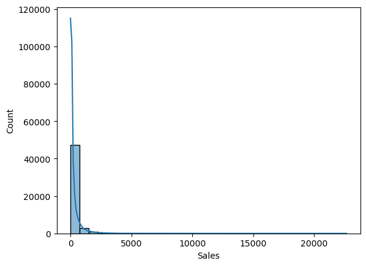

```python
# Sales Distribution
sns.histplot(store['Sales'],
             bins=30,
             kde=True)
plt.show()
```

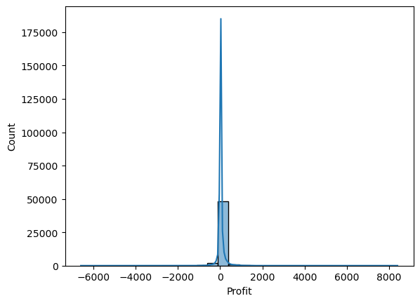

```python
# Profit Distribution
sns.histplot(store['Profit'],
             bins=30,
             kde=True)
plt.show()
```

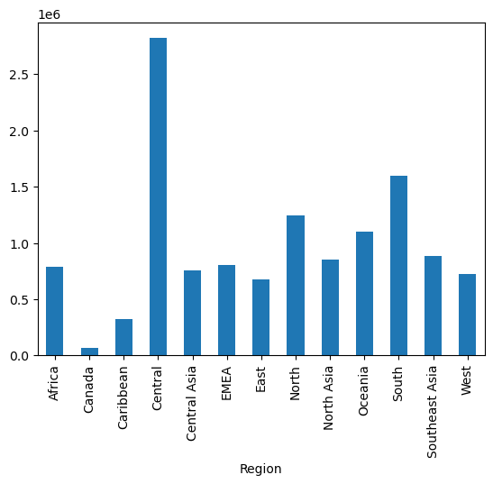

```python
# Sales by Region
region_sales = store.groupby('Region')['Sales'].sum()

region_sales.plot(kind='bar')

plt.show()
```

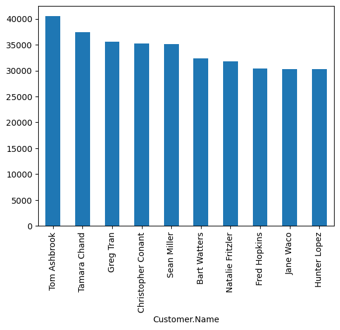

```python
# Top Customers
top_customers = (store.groupby('Customer.Name')['Sales']
    .sum()
    .sort_values(ascending=False)
    .head(10))

top_customers.plot(kind='bar')

plt.show()
```

## BUSINESS INSIGHTS AND RECOMMENDATIONS

## 1. Sales Performance

- The company generates substantial revenue across multiple markets and regions.
- Sales distribution is highly skewed, indicating that a relatively small number of transactions contribute disproportionately to overall revenue.
- High-value orders significantly influence total sales performance.

## 2. Profitability Analysis

- Profit distribution reveals the presence of both profitable and loss-making transactions.
- While most transactions generate positive profit, some sales result in losses, likely due to high discounts or operational costs. This indicates opportunities to improve pricing and discount strategies.

## 3. Regional Performance

Based on the regional sales chart:

- Certain regions consistently outperform others in total sales.
- The highest-performing regions represent key revenue drivers for the business.
- Lower-performing regions may require targeted sales and marketing interventions.

## Recommendations

1. Customer Retention
   - Develop loyalty and retention programs targeting top customers.
   - Provide personalized offers and premium services for high-value accounts.
2. Regional Growth Strategy
   - Investigate factors driving strong performance in top regions.
   - Replicate successful strategies in lower-performing regions where feasible.
3. Profitability Improvement
   - Review discount policies associated with low-profit transactions.
   - Focus marketing efforts on high-margin products and categories.
4. Inventory Optimization
   - Prioritize inventory allocation toward consistently high-performing products.
   - Reduce stock levels for underperforming product categories.
5. Dashboard Utilization
   - Encourage business stakeholders to use the Streamlit dashboard for real-time monitoring of:
     - Sales performance
     - Profitability trends
     - Customer contributions
     - Regional performance